# Statistical and Machine Learning Models

Session 2: Homework

**Install/Import Required Packages**

```r
suppressMessages({
  if(!require(knitr)){install.packages("knitr")}
  if(!require(ggplot2)){install.packages("ggplot2")}
  if(!require(rpart)){install.packages("rpart")}
  if(!require(rpart.plot)){install.packages("rpart.plot")}
  if(!require(randomForest)){install.packages("randomForest")}
  if(!require(caret)){install.packages("caret")}
  if(!require(factoextra)){install.packages("factoextra")}
  if(!require(FactoMineR)){install.packages("FactoMineR")}
  if (!require("pROC")) {install.packages("pROC")}
  if (!require("ggdendro")) {install.packages("ggdendro")}
  if (!require("mlbench")) {install.packages("mlbench")}
  if (!require("BiocManager", quietly = TRUE)) {install.packages("BiocManager")}
  if (!require("GEOquery", quietly = TRUE)) {install.packages("GEOquery")}
  if (!require("pheatmap", quietly = TRUE)) {install.packages("pheatmap")}
  if (!require("NHANES", quietly = TRUE)) {install.packages("NHANES")}

  library(knitr)
  library(ggplot2)
  library(rpart)
  library(rpart.plot)
  library(randomForest)
  library(caret)
  library(factoextra)
  library(FactoMineR)
  library(pROC)
  library(ggdendro)
  library(mlbench)
  library(BiocManager)
  library(GEOquery)
  library(pheatmap)
  library(NHANES)

})
```

# Supervised Learning

## Linear Regression

### Lets Load Data Set

```r
library(NHANES)

blood_pressure_df = data.frame(NHANES::NHANES)[c("Age","BMI","Pulse","BPSysAve")][1:500,]

blood_pressure_df = na.omit(blood_pressure_df)

kable(head(blood_pressure_df, 10),caption = "NCHS Survey Data of 500 People")
```

NCHS Survey Data of 500 People

|  | Age | BMI | Pulse | BPSysAve |
| --- | --- | --- | --- | --- |
| 1 | 34 | 32.22 | 70 | 113 |
| 2 | 34 | 32.22 | 70 | 113 |
| 3 | 34 | 32.22 | 70 | 113 |
| 5 | 49 | 30.57 | 86 | 112 |
| 6 | 9 | 16.82 | 82 | 86 |
| 7 | 8 | 20.64 | 72 | 107 |
| 8 | 45 | 27.24 | 62 | 118 |
| 9 | 45 | 27.24 | 62 | 118 |
| 10 | 45 | 27.24 | 62 | 118 |
| 11 | 66 | 23.67 | 60 | 111 |

- `Age` Age in years at screening of study participant. Note: Subjects 80 years or older were recorded as 80.
- `BMI` Body mass index (weight/height2 in kg/m2). Reported for participants aged 2 years or older.
- `Pulse` 60 second pulse rate
- `BPSysAve` Combined systolic blood pressure reading, following the procedure outlined for BPXSAR.

**The column names of the data set are: `Age`,`BMI`,`Pulse`, and `BPSysAve`**

### Problem 1: Writing a `R` code to get the following Scatter plot using ggplot2 package

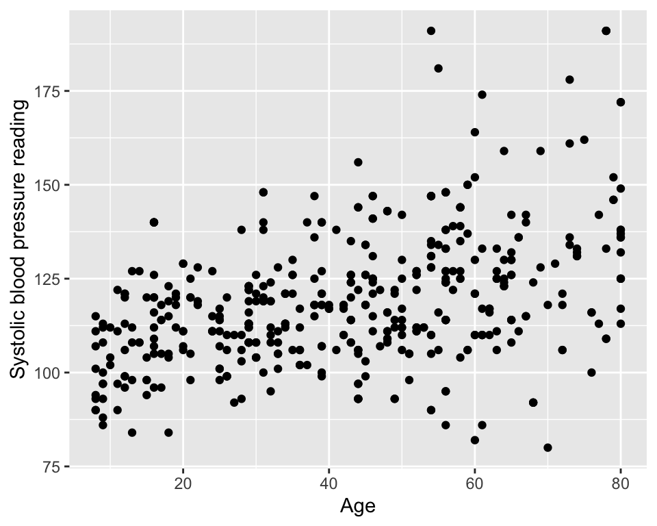

### Problem 2: Perform a Simple Linear Regression Model for Blood Pressure (i.e., `BPSysAve`) as Response variable and Age as the predictor variable (i.e., `Age`A)

### Problem 3: What is the regression equation in the simple linear regression model in Problem 2

### Problem 4: What correlation coefficient of Problem in the simple linear regression model in Problem 2

### Problem 4: Using the following `R` code, perform a Multiple Linear Regression Model for Blood Pressure (i.e., `BPSysAve`) as the Response variable and all other variables as predictor variables

```r
multiple_linear_regression = lm(formula = BPSysAve ~. ,data = blood_pressure_df)
summary(multiple_linear_regression)
```

[output not shown]

**Backward Elimination**

```r
library(MASS)
backward_model = stepAIC(multiple_linear_regression, direction = "backward", trace = FALSE)
summary(backward_model)
```

[output not shown]

### Problem 9: Runf the following `R` code to apply the random forrest regression model to for the data set ‘blood_pressure_df’ as use `BPSysAve` as the response variable

```r
library(randomForest)
Random_Forest_model = randomForest(formula = BPSysAve ~. ,data = blood_pressure_df, ntree=500, importance=TRUE)
```

### Problem 10: Get the variable importance using the following `R` code and explain which variables are important.

```r
important_features = as.data.frame(importance(Random_Forest_model))

important_features$feature_name = row.names(important_features)

ggplot(important_features, aes(x=feature_name, y=`%IncMSE`)) +
  geom_segment( aes(x=feature_name, xend=feature_name, y=0, yend=`%IncMSE`), color="orange") +
  geom_point(aes(size = IncNodePurity), color="darkorange", alpha=0.9) +
  theme_minimal() +
  coord_flip() +
  theme( legend.position="None") +
  xlab('Features') + ylab('Importance')
```

[output not shown]

## Classification

### Lets Load `PimaIndiansDiabetes` Data Set for Classification

```r
data(PimaIndiansDiabetes)
kable(head(PimaIndiansDiabetes, 10),caption = "A data frame with 768 observations on 9 variables.")
```

A data frame with 768 observations on 9 variables.

| pregnant | glucose | pressure | triceps | insulin | mass | pedigree | age | diabetes |
| --- | --- | --- | --- | --- | --- | --- | --- | --- |
| 6 | 148 | 72 | 35 | 0 | 33.6 | 0.627 | 50 | pos |
| 1 | 85 | 66 | 29 | 0 | 26.6 | 0.351 | 31 | neg |
| 8 | 183 | 64 | 0 | 0 | 23.3 | 0.672 | 32 | pos |
| 1 | 89 | 66 | 23 | 94 | 28.1 | 0.167 | 21 | neg |
| 0 | 137 | 40 | 35 | 168 | 43.1 | 2.288 | 33 | pos |
| 5 | 116 | 74 | 0 | 0 | 25.6 | 0.201 | 30 | neg |
| 3 | 78 | 50 | 32 | 88 | 31.0 | 0.248 | 26 | pos |
| 10 | 115 | 0 | 0 | 0 | 35.3 | 0.134 | 29 | neg |
| 2 | 197 | 70 | 45 | 543 | 30.5 | 0.158 | 53 | pos |
| 8 | 125 | 96 | 0 | 0 | 0.0 | 0.232 | 54 | pos |

- `pregnant` Number of times pregnant
- `glucose` Plasma glucose concentration (glucose tolerance test)
- `pressure` Diastolic blood pressure (mm Hg)
- `triceps` Triceps skin fold thickness (mm)
- `insulin` 2-Hour serum insulin (mu U/ml)
- `mass` Body mass index (weight in kg/(height in m)^2)
- `pedigree` Diabetes pedigree function
- `age` Age (years)
- `diabetes` Class variable (test for diabetes)

### Problem 11: Model `PimaIndiansDiabetes` data set using Logistic regression where the response variable is `diabetes`

```r
logistic_regression = glm(formula = diabetes ~ .,
                          data = PimaIndiansDiabetes,family = 'binomial')

summary(logistic_regression)
```

[output not shown]

### Problem 12: Using the the Logistic Regression Model in the Problem 11, which variables are significant.

### Problem 13: Can you interpret the coefficient estimate for `glucose`?

### Problem 14: Use the following `R` code to model the `PimaIndiansDiabetes` data set using the Random Forest Classifier where the response variable is `diabetes`

```r
library(randomForest)
Random_Forest_Classifier = randomForest(diabetes ~ ., data=PimaIndiansDiabetes, ntree=500, importance = TRUE)
```

### Problem 15: Run the following `R` code to exaplain the variable importance for the model obtained from the Random Forest Classifier

```r
important_features = as.data.frame(importance(Random_Forest_Classifier))

important_features$feature_name <- row.names(important_features)

ggplot(important_features, aes(x=feature_name, y=`MeanDecreaseGini`)) +
  geom_segment( aes(x=feature_name, xend=feature_name, y=0, yend=`MeanDecreaseGini`), color="orange") +
  geom_point(aes(size = MeanDecreaseAccuracy), color="darkorange", alpha=0.9) +
  theme_minimal() +
  coord_flip() +
  theme(legend.position = "none") +
  xlab('Features') + ylab('Importance')
```

[output not shown]

# Unsupervised Learning

### Lets Load `PimaIndiansDiabetes` Data Set

```r
data(PimaIndiansDiabetes)

# data without diabetes column
pima_indians_df = PimaIndiansDiabetes[,-9]

# diabetes column
diabetes = PimaIndiansDiabetes[,9]
```

## K-Means Clustering

### Problem 16: Apply K-means clustering with 2 clusters for `pima_indians_df` data set and plot the results using the following `R` code

```r
set.seed(123)
library(factoextra)

k_means_clustering = kmeans(pima_indians_df, centers = 2)
fviz_cluster(k_means_clustering, data = pima_indians_df)
```

[output not shown]